# Introduction To R (Statistical Learning Book)

Alona Varshal

4/19/2017

## Basic Commands

Assigning to variables

```r
x <- c(1, 3, 2, 5)
x
```

```
## [1] 1 3 2 5
```

We can also use the equal sign “=”:

```r
x = c(1, 6, 2)
x
```

```
## [1] 1 6 2
```

Determining the lengths of vectors:

```r
y = c(1, 4, 3)
length(x)
```

```
## [1] 3
```

```r
length(y)
```

```
## [1] 3
```

Adding vectors

```r
x+y
```

```
## [1]  2 10  5
```

Listing variables available:

```r
ls()
```

```
## [1] "x" "y"
```

Deleting variables:

```r
rm(x,y)
ls()
```

```
## character(0)
```

To get information about a certain function:

```r
?matrix
```

Creating matrices:

```r
x = matrix(data=c(1, 2, 3, 4), nrow=2, ncol=2)
x
```

```
##      [,1] [,2]
## [1,]    1    3
## [2,]    2    4
```

```r
x = matrix(c(1,2,3,4), 2, 2)
x
```

```
##      [,1] [,2]
## [1,]    1    3
## [2,]    2    4
```

```r
matrix(c(1,2,3,4), 2,2,byrow=TRUE)
```

```
##      [,1] [,2]
## [1,]    1    2
## [2,]    3    4
```

Operations on matrices

```r
sqrt(x)
```

```
##          [,1]     [,2]
## [1,] 1.000000 1.732051
## [2,] 1.414214 2.000000
```

```r
x^2
```

```
##      [,1] [,2]
## [1,]    1    9
## [2,]    4   16
```

The rnorm function generates a vector or random variables.

```r
x = rnorm(50)
x
```

```
##  [1] -0.38189618  0.32828540  1.36861918 -0.63825686 -0.68041171
##  [6] -0.85647273  1.56168273  2.36176275 -1.09663091  0.42033838
## [11]  1.04338145 -1.69607420 -1.71355916 -0.61907963 -0.69503877
## [16] -0.32213040  0.22108214  1.65718244  0.65139847  0.89494091
## [21] -0.36014991  1.34056986  0.19103316  2.08609981 -0.34598381
## [26] -0.25896283 -1.09854587  1.32184325  1.01052956  0.44821526
## [31]  0.02274021 -0.48833037  0.53770325  1.26269256 -1.63950691
## [36]  1.57920396  1.08661058  0.08845083  2.39842956  1.47699699
## [41]  0.81628296  0.42407681 -1.24074025  0.77357923 -1.18033573
## [46]  1.86131719  0.91573638  0.62632342  1.90786408 -0.62250499
```

```r
y=x+rnorm(n=50, mean=50, sd=.1)
cor(x,y)
```

```
## [1] 0.9963086
```

By default, rnorm() creates standard normal random variables with a mean of 0 and a standard deviation of 1. However, the mean and standard deviation can be altered using the `mean` and `sd` arguments. Sometimes, we want to reproduce the exact same set of random numbers. We can do this using `set.seed()` function. It takes an arbitrary integer argument.

```r
set.seed(1303)
rnorm(50)
```

```
##  [1] -1.1439763145  1.3421293656  2.1853904757  0.5363925179  0.0631929665
##  [6]  0.5022344825 -0.0004167247  0.5658198405 -0.5725226890 -1.1102250073
## [11] -0.0486871234 -0.6956562176  0.8289174803  0.2066528551 -0.2356745091
## [16] -0.5563104914 -0.3647543571  0.8623550343 -0.6307715354  0.3136021252
## [21] -0.9314953177  0.8238676185  0.5233707021  0.7069214120  0.4202043256
## [26] -0.2690521547 -1.5103172999 -0.6902124766 -0.1434719524 -1.0135274099
## [31]  1.5732737361  0.0127465055  0.8726470499  0.4220661905 -0.0188157917
## [36]  2.6157489689 -0.6931401748 -0.2663217810 -0.7206364412  1.3677342065
## [41]  0.2640073322  0.6321868074 -1.3306509858  0.0268888182  1.0406363208
## [46]  1.3120237985 -0.0300020767 -0.2500257125  0.0234144857  1.6598706557
```

`mean()` and `var()` functions:

```r
set.seed(3)
y = rnorm(100)
mean(y)
```

```
## [1] 0.01103557
```

```r
var(y)
```

```
## [1] 0.7328675
```

```r
sqrt(var(y))
```

```
## [1] 0.8560768
```

```r
sd(y)
```

```
## [1] 0.8560768
```

### Graphics

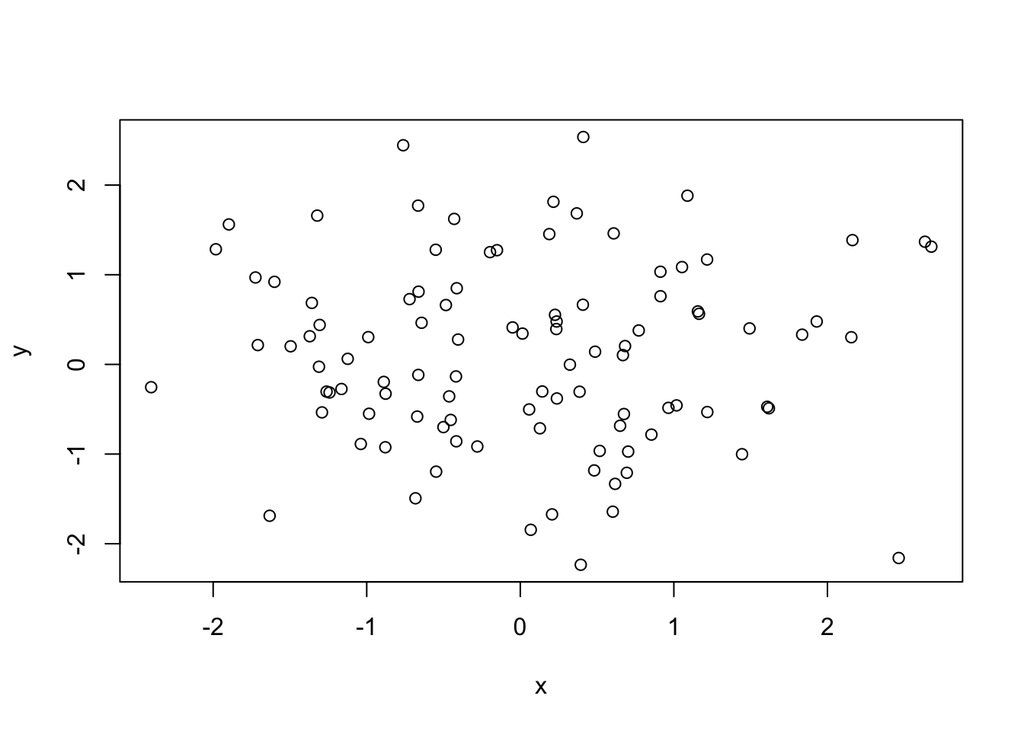

```r
x = rnorm(100)
y = rnorm(100)
plot(x, y)
```

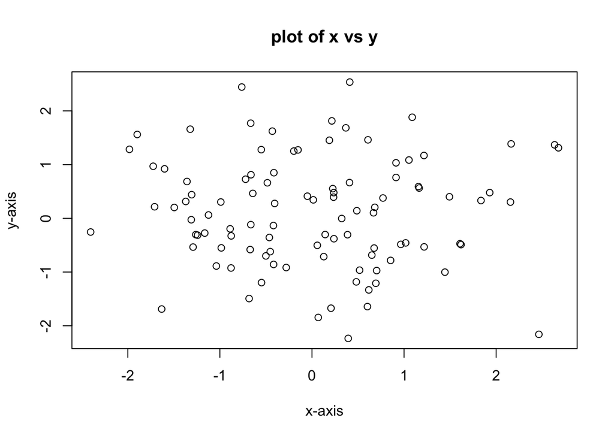

```r
plot(x, y, xlab = "x-axis", ylab="y-axis", main="plot of x vs y")
```

Saving plots using `pdf()` and `jpeg()` functions

```r
pdf("Figure.pdf")
plot(x,y, col="green")
dev.off()
```

`dev.off()` indicates to R that we are done creating the plot.

`seq(a,b)` makes a vector of integers between `a` and `b`.

```r
x = seq(1,10)
x
```

```
##  [1]  1  2  3  4  5  6  7  8  9 10
```

“length” is an additional argument for `seq()`:

```r
seq(0,1, length=10)
```

```
##  [1] 0.0000000 0.1111111 0.2222222 0.3333333 0.4444444 0.5555556 0.6666667
##  [8] 0.7777778 0.8888889 1.0000000
```

```r
x = seq(1,10)
x
```

```
##  [1]  1  2  3  4  5  6  7  8  9 10
```

```r
x = 1:10
x
```

```
##  [1]  1  2  3  4  5  6  7  8  9 10
```

```r
x = seq(-pi, pi, length=50)
x
```

```
##  [1] -3.14159265 -3.01336438 -2.88513611 -2.75690784 -2.62867957
##  [6] -2.50045130 -2.37222302 -2.24399475 -2.11576648 -1.98753821
## [11] -1.85930994 -1.73108167 -1.60285339 -1.47462512 -1.34639685
## [16] -1.21816858 -1.08994031 -0.96171204 -0.83348377 -0.70525549
## [21] -0.57702722 -0.44879895 -0.32057068 -0.19234241 -0.06411414
## [26]  0.06411414  0.19234241  0.32057068  0.44879895  0.57702722
## [31]  0.70525549  0.83348377  0.96171204  1.08994031  1.21816858
## [36]  1.34639685  1.47462512  1.60285339  1.73108167  1.85930994
## [41]  1.98753821  2.11576648  2.24399475  2.37222302  2.50045130
## [46]  2.62867957  2.75690784  2.88513611  3.01336438  3.14159265
```

Contour plot:

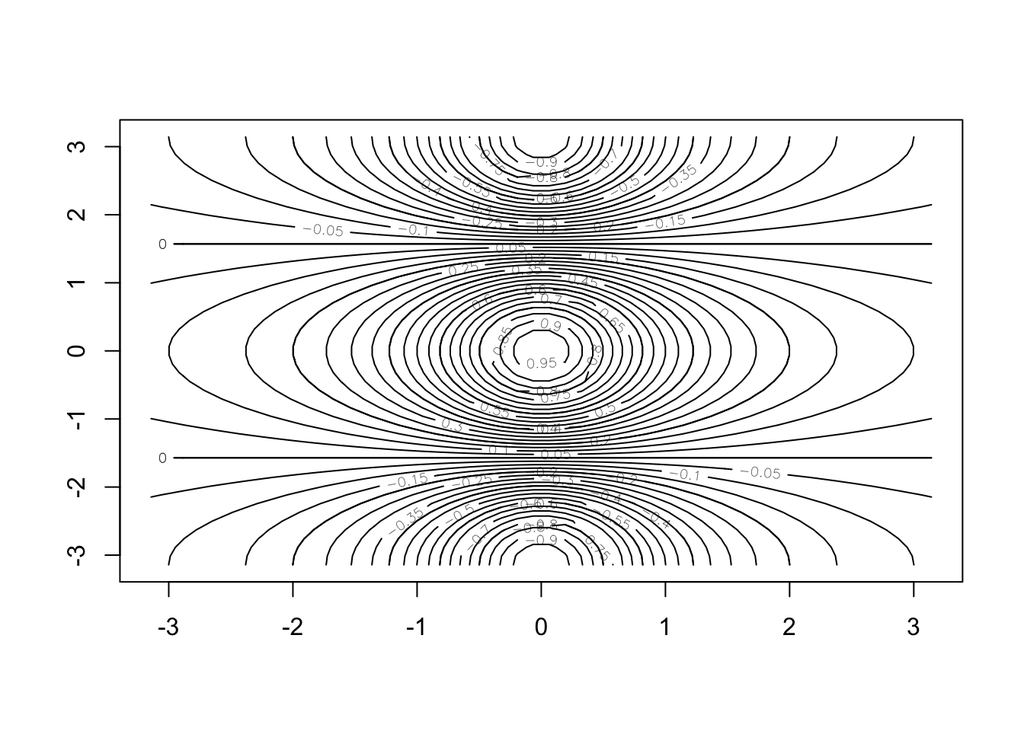

```r
y=x
f=outer(x,y, function(x,y)cos(y)/(1 + x^2))
contour(x,y,f)
contour(x,y,f,nlevels=45,add = T)
```

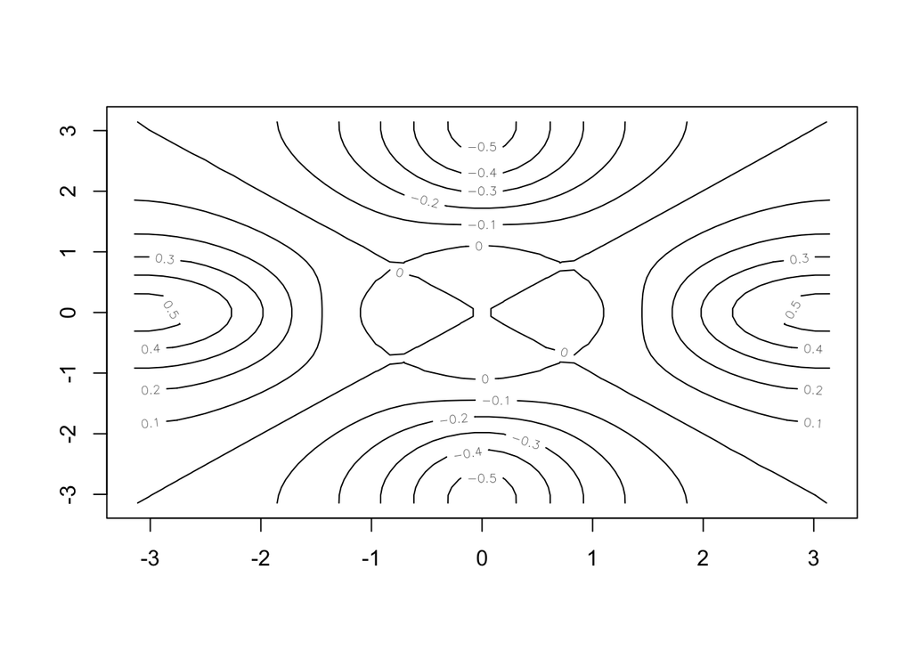

```r
fa=(f-t(f))/2
contour(x,y,fa,nlevels = 15)
```

Heatmaps:

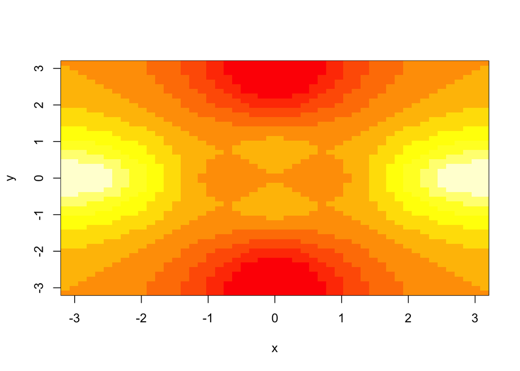

```r
image(x,y,fa)
```

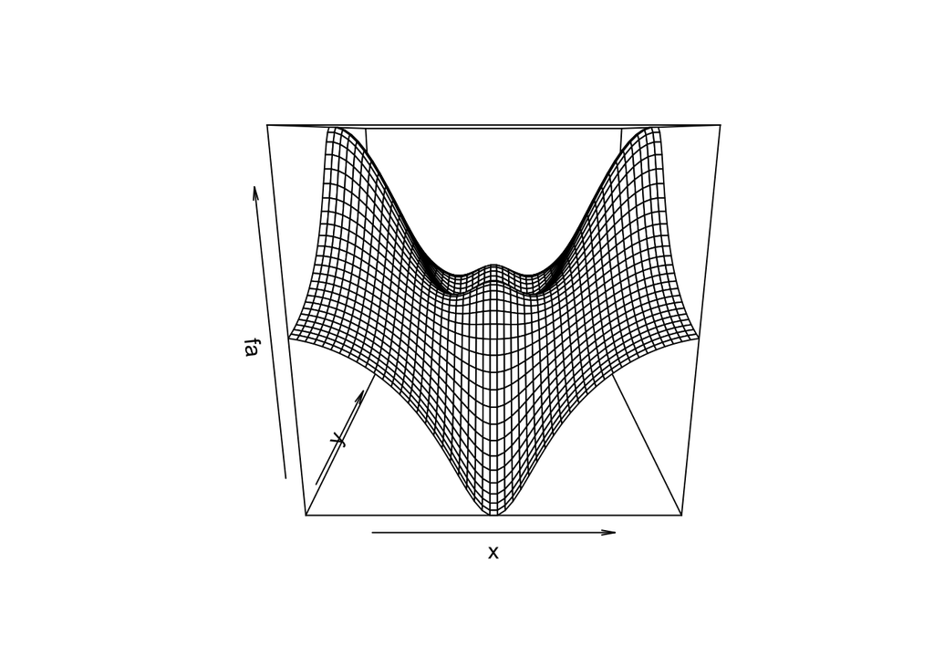

```r
persp(x,y,fa)
```

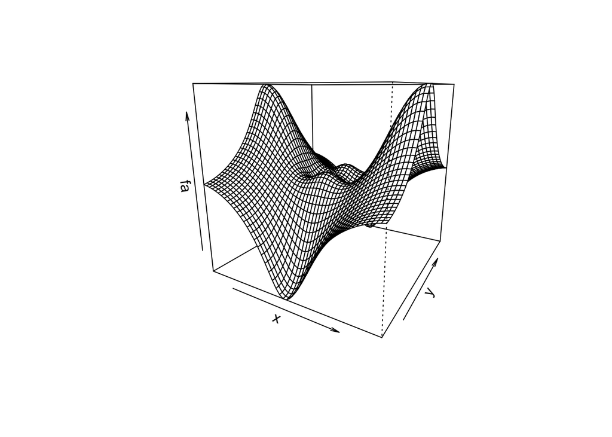

```r
persp(x,y,fa, theta = 30)
```

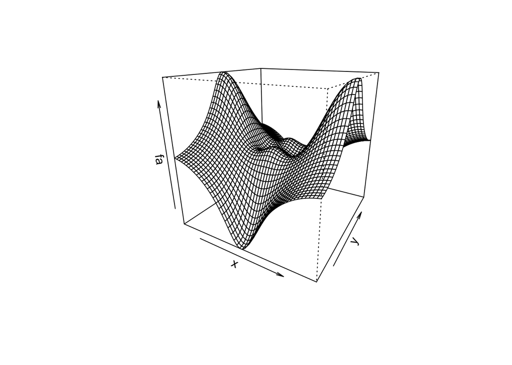

```r
persp(x,y,fa, theta = 30, phi = 20)
```

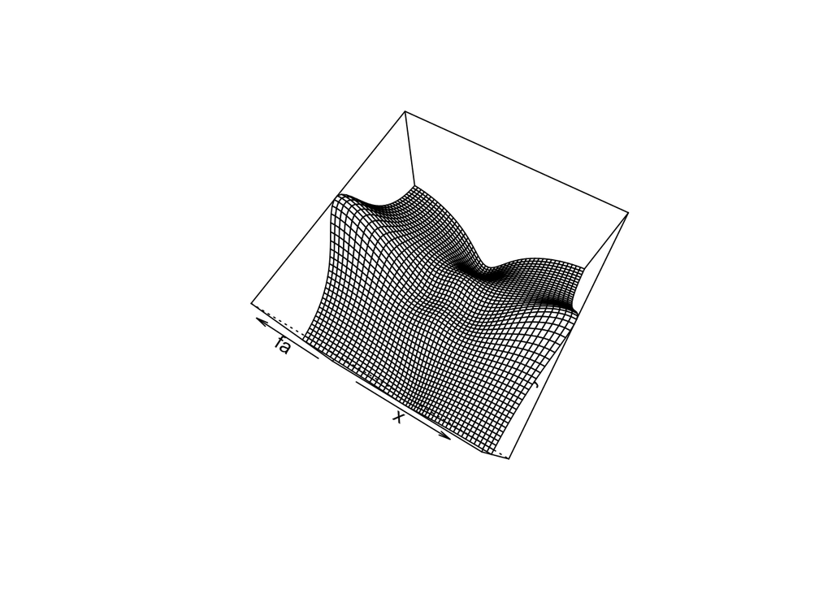

```r
persp(x,y,fa, theta = 30, phi = 70)
```

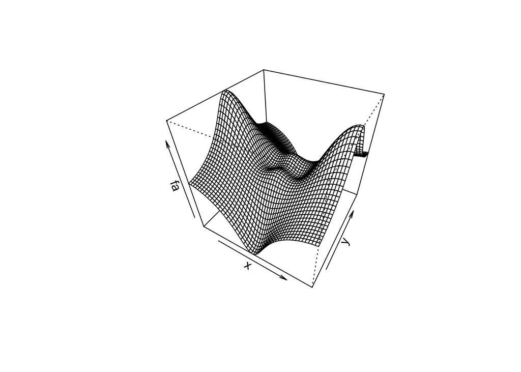

```r
persp(x,y,fa, theta = 30, phi = 40)
```

Arguments theta and pi control the angles at which the plot is viewed.

## Indexing Data

```r
A = matrix(1:16, 4,4)
A
```

```
##      [,1] [,2] [,3] [,4]
## [1,]    1    5    9   13
## [2,]    2    6   10   14
## [3,]    3    7   11   15
## [4,]    4    8   12   16
```

```r
A[2,3]
```

```
## [1] 10
```

```r
A[c(1,3), c(2,4)]
```

```
##      [,1] [,2]
## [1,]    5   13
## [2,]    7   15
```

```r
A[1:3, 2:4]
```

```
##      [,1] [,2] [,3]
## [1,]    5    9   13
## [2,]    6   10   14
## [3,]    7   11   15
```

```r
A[1:2,]
```

```
##      [,1] [,2] [,3] [,4]
## [1,]    1    5    9   13
## [2,]    2    6   10   14
```

```r
A[,1:2]
```

```
##      [,1] [,2]
## [1,]    1    5
## [2,]    2    6
## [3,]    3    7
## [4,]    4    8
```

```r
A[1,]
```

```
## [1]  1  5  9 13
```

The use of a negative sign in the index tells R to keep all rows or columns except those indicated in the index.

```r
A
```

```
##      [,1] [,2] [,3] [,4]
## [1,]    1    5    9   13
## [2,]    2    6   10   14
## [3,]    3    7   11   15
## [4,]    4    8   12   16
```

```r
A[-c(1,3)]
```

```
##  [1]  2  4  5  6  7  8  9 10 11 12 13 14 15 16
```

```r
A[-c(1,3), -c(1,3,4)]
```

```
## [1] 6 8
```

`dim()` function outputs the number of rows followed by the number of columms of a given matrix.

```r
dim(A)
```

```
## [1] 4 4
```

## Loading Data

Make sure to download Auto.data from http://www-bcf.usc.edu/~gareth/ISL/data.html and place in appropriate folder. Also, make sure X11 is installed.

```r
Auto = read.table("Auto.data")
# `fix` command opens a window that shows the spreadsheet.
fix(Auto)
```

Quit the spreadsheet before running the next commands.